# Test a Perceptual Phenomenon

### Analyzing the Stroop Effect

Perform the analysis in the space below. Remember to follow [the instructions](https://docs.google.com/document/d/1-OkpZLjG_kX9J6LIQ5IltsqMzVWjh36QpnP2RYpVdPU/pub?embedded=True) and review the [project rubric](https://review.udacity.com/#!/rubrics/71/view) before submitting. Once you've completed the analysis and write-up, download this file as a PDF or HTML file, upload that PDF/HTML into the workspace here (click on the orange Jupyter icon in the upper left then Upload), then use the Submit Project button at the bottom of this page. This will create a zip file containing both this .ipynb doc and the PDF/HTML doc that will be submitted for your project.

(1) What is the independent variable? What is the dependent variable?

**Independent Variable:** congruent words condition and incongruent words condition

**Dependent Variable:** Time it takes by participants to name the ink colors

(2) What is an appropriate set of hypotheses for this task? Specify your null and alternative hypotheses, and clearly define any notation used. Justify your choices.

**Null Hypothesis:** µc >= µi , congruent response time is bigger than or equal to incongruent response time.

**Alternative Hypothesis:** µc < µi , incongruent response time is bigger than congruent response time.

**The reason of choosing t-test:** The sample size is less than 30 and the population standard deviations is unknown

The means of two related groups will be cpmpared to statistically determine the difference between two means.

Distributions are assumed to be nearly normal and 2 dependent samples of data will be compared

(3) Report some descriptive statistics regarding this dataset. Include at least one measure of central tendency and at least one measure of variability. The name of the data file is 'stroopdata.csv'.

```python
#Import required packages
import csv
import pandas as pd
import matplotlib.pyplot as plt
import numpy as np
import math
from scipy.stats import t


# read stroopdata.csv
stroopdata_df = pd.read_csv('stroopdata.csv')
stroopdata_df.head()
```

|  | Congruent | Incongruent |
| --- | --- | --- |
| 0 | 12.079 | 19.278 |
| 1 | 16.791 | 18.741 |
| 2 | 9.564 | 21.214 |
| 3 | 8.630 | 15.687 |
| 4 | 14.669 | 22.803 |

```python
#Measures of central tendency, Mean

stroopdata_df.mean()
```

```
Congruent      14.051125
Incongruent    22.015917
dtype: float64
```

```python
#Measures of central tendency, Median

stroopdata_df.median()
```

```
Congruent      14.3565
Incongruent    21.0175
dtype: float64
```

```python
#Measures of central tendency, Mode

stroopdata_df.mode()
```

|  | Congruent | Incongruent |
| --- | --- | --- |
| 0 | 8.630 | 15.687 |
| 1 | 8.987 | 17.394 |
| 2 | 9.401 | 17.425 |
| 3 | 9.564 | 17.510 |
| 4 | 10.639 | 17.960 |
| 5 | 11.344 | 18.644 |
| 6 | 12.079 | 18.741 |
| 7 | 12.130 | 19.278 |
| 8 | 12.238 | 20.330 |
| 9 | 12.369 | 20.429 |
| 10 | 12.944 | 20.762 |
| 11 | 14.233 | 20.878 |
| 12 | 14.480 | 21.157 |
| 13 | 14.669 | 21.214 |
| 14 | 14.692 | 22.058 |
| 15 | 15.073 | 22.158 |
| 16 | 15.298 | 22.803 |
| 17 | 16.004 | 23.894 |
| 18 | 16.791 | 24.524 |
| 19 | 16.929 | 24.572 |
| 20 | 18.200 | 25.139 |
| 21 | 18.495 | 26.282 |
| 22 | 19.710 | 34.288 |
| 23 | 22.328 | 35.255 |

```python
#Measures of variability, Standard Diviation

stroopdata_df.std()
```

```
Congruent      3.559358
Incongruent    4.797057
dtype: float64
```

(4) Provide one or two visualizations that show the distribution of the sample data. Write one or two sentences noting what you observe about the plot or plots.

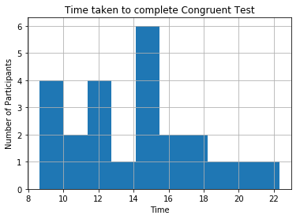

```python
# Histogram shows the amount of time taken to complete the Congruent Test

stroopdata_df['Congruent'].hist()
plt.xlabel('Time')
plt.ylabel('Number of Participants')
plt.title('Time taken to complete Congruent Test');
plt.show()
```

```python
#Check the max amount of time of Congruent test

stroopdata_df['Congruent'].max()
```

```
22.328000000000003
```

```python
#Check the min amount of time of Congruent test

stroopdata_df['Congruent'].min()
```

```
8.6300000000000008
```

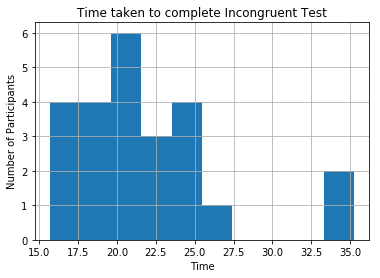

```python
# Histogram shows the amount of time taken to complete the Incongruent Test

stroopdata_df['Incongruent'].hist()
plt.xlabel('Time')
plt.ylabel('Number of Participants')
plt.title('Time taken to complete Incongruent Test');
plt.show()
```

```python
#Check the max amount of time of Incongruent test

stroopdata_df['Incongruent'].max()
```

```
35.255000000000003
```

```python
#Check the min amount of time of Incongruent test

stroopdata_df['Incongruent'].min()
```

```
15.687000000000001
```

(5) Now, perform the statistical test and report your results. What is your confidence level or Type I error associated with your test? What is your conclusion regarding the hypotheses you set up? Did the results match up with your expectations? **Hint:** Think about what is being measured on each individual, and what statistic best captures how an individual reacts in each environment.

```python
# T-test is the best statistical test for this case

#Calculate the mean of congruent and incongruent tests

C_mean = np.mean(stroopdata_df.Congruent)
In_mean = np.mean(stroopdata_df.Incongruent)

print(" Mean value of Congruent is {0} \n Mean value of Incongruent is {1} ".format(C_mean,In_mean))
```

```
 Mean value of Congruent is 14.051124999999999
 Mean value of Incongruent is 22.015916666666666
```

```python
#Calculate the length of congruent and incongruent tests
n1=len(stroopdata_df.Congruent)
n2=len(stroopdata_df.Incongruent)
print(n1)
print(n2)
```

```
24
24
```

```python
#The critical value for a 95% confidence level and 23 d.f.
t.ppf(.95, 23)
```

```
1.7138715277470473
```

```python
stroopdata_df['Difference'] = stroopdata_df['Congruent'] - stroopdata_df['Incongruent']
print("standard deviation for congruent {0:.4f}".format(stroopdata_df['Difference'].std(axis=0)))
```

[output not shown]

**From above calculations we can infer the following:**

1- The mean of congruent sample is 14.05.

2- The mean of Incongruent sample is 22.01.

3- The size of two samples is 24.

4- The critical value is 1.71.

```python
## Final Calculation, t - value = (Difference between the means/variability of group)

7.97/(4.8648 / math.sqrt(24))
```

```
8.025996238275749
```

**Rule:**

If the t-value is less than critical -- fail to reject the null hypothesis.

If the t-value is more than critical-- reject the null hypothesis.

we suppose that the confidence interval is 95% = 0.95

**Conclusion**

Calculated T value is approximately 8.02 which is higher than the critical value 1.71 so,null hypothesis is rejected.

So, "There exists a statistic difference between the amounts of time taken to complete the congruent and incongruent tests"

**Resources**

1- How to specify dependent and independent variables

https://www.youtube.com/watch?v=aeH1FzqdQZ0&pbjreload=10

2- T-test

https://www.youtube.com/watch?v=TYgYWcHdLAc https://github.com/shyamragcp/T_test/blob/master/T_test.ipynb

3- Finding the critical value using t-table

http://davidmlane.com/hyperstat/t_table.html